# Data analysis project example

## Exploratory Analysis

### Read data, quick look

```r
d <- read_csv("ds_project_example/data/credit.csv")
dim(d)
```

```
## [1] 150000     12
```

```r
head(d)
```

```
## Source: local data frame [6 x 12]
##
##      NA SeriousDlqin2yrs RevolvingUtilizationOfUnsecuredLines   age
##   (int)            (int)                                (dbl) (int)
## 1     1                1                            0.7661266    45
## 2     2                0                            0.9571510    40
## 3     3                0                            0.6581801    38
## 4     4                0                            0.2338098    30
## 5     5                0                            0.9072394    49
## 6     6                0                            0.2131787    74
## Variables not shown: NumberOfTime30-59DaysPastDueNotWorse (int), DebtRatio
##   (dbl), MonthlyIncome (int), NumberOfOpenCreditLinesAndLoans (int),
##   NumberOfTimes90DaysLate (int), NumberRealEstateLoansOrLines (int),
##   NumberOfTime60-89DaysPastDueNotWorse (int), NumberOfDependents (int)
```

```r
d[[1]] <- NULL
dim(d)
```

```
## [1] 150000     11
```

```r
head(d)
```

```
## Source: local data frame [6 x 11]
##
##   SeriousDlqin2yrs RevolvingUtilizationOfUnsecuredLines   age
##              (int)                                (dbl) (int)
## 1                1                            0.7661266    45
## 2                0                            0.9571510    40
## 3                0                            0.6581801    38
## 4                0                            0.2338098    30
## 5                0                            0.9072394    49
## 6                0                            0.2131787    74
## Variables not shown: NumberOfTime30-59DaysPastDueNotWorse (int), DebtRatio
##   (dbl), MonthlyIncome (int), NumberOfOpenCreditLinesAndLoans (int),
##   NumberOfTimes90DaysLate (int), NumberRealEstateLoansOrLines (int),
##   NumberOfTime60-89DaysPastDueNotWorse (int), NumberOfDependents (int)
```

```r
str(d)
```

```
## Classes 'tbl_df', 'tbl' and 'data.frame':    150000 obs. of  11 variables:
##  $ SeriousDlqin2yrs                    : int  1 0 0 0 0 0 0 0 0 0 ...
##  $ RevolvingUtilizationOfUnsecuredLines: num  0.766 0.957 0.658 0.234 0.907 ...
##  $ age                                 : int  45 40 38 30 49 74 57 39 27 57 ...
##  $ NumberOfTime30-59DaysPastDueNotWorse: int  2 0 1 0 1 0 0 0 0 0 ...
##  $ DebtRatio                           : num  0.803 0.1219 0.0851 0.036 0.0249 ...
##  $ MonthlyIncome                       : int  9120 2600 3042 3300 63588 3500 NA 3500 NA 23684 ...
##  $ NumberOfOpenCreditLinesAndLoans     : int  13 4 2 5 7 3 8 8 2 9 ...
##  $ NumberOfTimes90DaysLate             : int  0 0 1 0 0 0 0 0 0 0 ...
##  $ NumberRealEstateLoansOrLines        : int  6 0 0 0 1 1 3 0 0 4 ...
##  $ NumberOfTime60-89DaysPastDueNotWorse: int  0 0 0 0 0 0 0 0 0 0 ...
##  $ NumberOfDependents                  : int  2 1 0 0 0 1 0 0 NA 2 ...
```

```r
colnames(d)
```

```
##  [1] "SeriousDlqin2yrs"
##  [2] "RevolvingUtilizationOfUnsecuredLines"
##  [3] "age"
##  [4] "NumberOfTime30-59DaysPastDueNotWorse"
##  [5] "DebtRatio"
##  [6] "MonthlyIncome"
##  [7] "NumberOfOpenCreditLinesAndLoans"
##  [8] "NumberOfTimes90DaysLate"
##  [9] "NumberRealEstateLoansOrLines"
## [10] "NumberOfTime60-89DaysPastDueNotWorse"
## [11] "NumberOfDependents"
```

```r
summary(d)
```

```
##  SeriousDlqin2yrs  RevolvingUtilizationOfUnsecuredLines      age
##  Min.   :0.00000   Min.   :    0.00                     Min.   :  0.0
##  1st Qu.:0.00000   1st Qu.:    0.03                     1st Qu.: 41.0
##  Median :0.00000   Median :    0.15                     Median : 52.0
##  Mean   :0.06684   Mean   :    6.05                     Mean   : 52.3
##  3rd Qu.:0.00000   3rd Qu.:    0.56                     3rd Qu.: 63.0
##  Max.   :1.00000   Max.   :50708.00                     Max.   :109.0
##
##  NumberOfTime30-59DaysPastDueNotWorse   DebtRatio        MonthlyIncome
##  Min.   : 0.000                       Min.   :     0.0   Min.   :      0
##  1st Qu.: 0.000                       1st Qu.:     0.2   1st Qu.:   3400
##  Median : 0.000                       Median :     0.4   Median :   5400
##  Mean   : 0.421                       Mean   :   353.0   Mean   :   6670
##  3rd Qu.: 0.000                       3rd Qu.:     0.9   3rd Qu.:   8249
##  Max.   :98.000                       Max.   :329664.0   Max.   :3008750
##                                                          NA's   :29731
##  NumberOfOpenCreditLinesAndLoans NumberOfTimes90DaysLate
##  Min.   : 0.000                  Min.   : 0.000
##  1st Qu.: 5.000                  1st Qu.: 0.000
##  Median : 8.000                  Median : 0.000
##  Mean   : 8.453                  Mean   : 0.266
##  3rd Qu.:11.000                  3rd Qu.: 0.000
##  Max.   :58.000                  Max.   :98.000
##
##  NumberRealEstateLoansOrLines NumberOfTime60-89DaysPastDueNotWorse
##  Min.   : 0.000               Min.   : 0.0000
##  1st Qu.: 0.000               1st Qu.: 0.0000
##  Median : 1.000               Median : 0.0000
##  Mean   : 1.018               Mean   : 0.2404
##  3rd Qu.: 2.000               3rd Qu.: 0.0000
##  Max.   :54.000               Max.   :98.0000
##
##  NumberOfDependents
##  Min.   : 0.000
##  1st Qu.: 0.000
##  Median : 0.000
##  Mean   : 0.757
##  3rd Qu.: 1.000
##  Max.   :20.000
##  NA's   :3924
```

```r
sapply(d, function(x) sum(is.na(x)))   ## NAs: MonthlyIncome, NumberOfDependents
```

```
##                     SeriousDlqin2yrs RevolvingUtilizationOfUnsecuredLines
##                                    0                                    0
##                                  age NumberOfTime30-59DaysPastDueNotWorse
##                                    0                                    0
##                            DebtRatio                        MonthlyIncome
##                                    0                                29731
##      NumberOfOpenCreditLinesAndLoans              NumberOfTimes90DaysLate
##                                    0                                    0
##         NumberRealEstateLoansOrLines NumberOfTime60-89DaysPastDueNotWorse
##                                    0                                    0
##                   NumberOfDependents
##                                 3924
```

```r
sapply(d, function(x) sum(x<0, na.rm=TRUE))    ## always >= 0
```

```
##                     SeriousDlqin2yrs RevolvingUtilizationOfUnsecuredLines
##                                    0                                    0
##                                  age NumberOfTime30-59DaysPastDueNotWorse
##                                    0                                    0
##                            DebtRatio                        MonthlyIncome
##                                    0                                    0
##      NumberOfOpenCreditLinesAndLoans              NumberOfTimes90DaysLate
##                                    0                                    0
##         NumberRealEstateLoansOrLines NumberOfTime60-89DaysPastDueNotWorse
##                                    0                                    0
##                   NumberOfDependents
##                                    0
```

[output not shown]

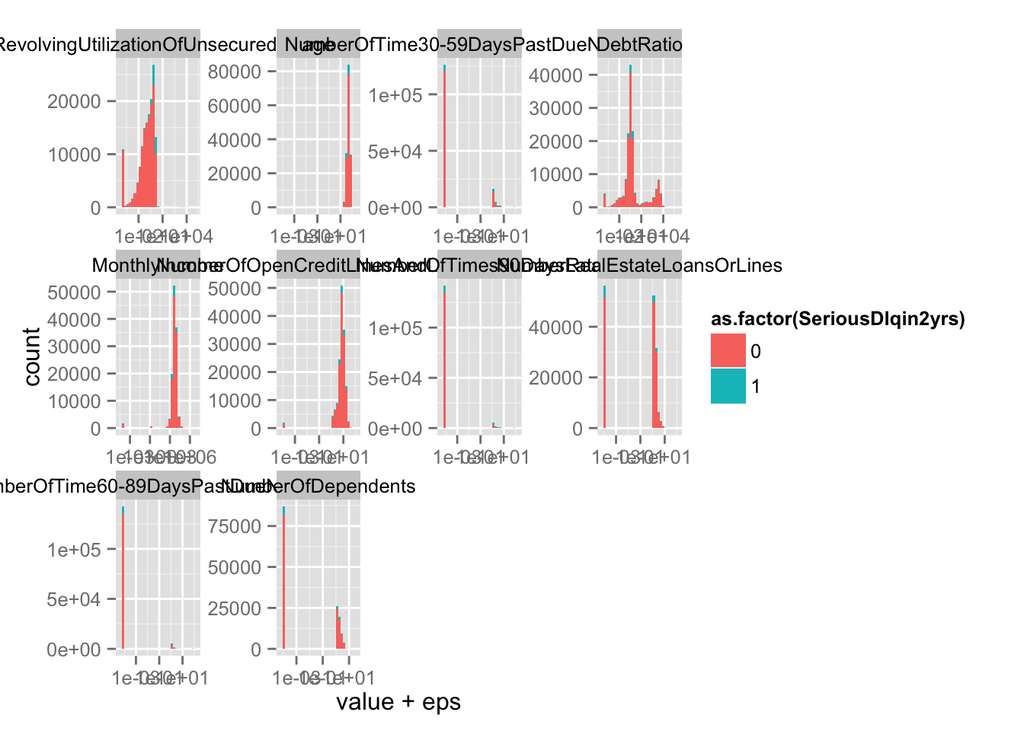

```r
eps <- 1e-4
d %>% melt(id.vars = "SeriousDlqin2yrs") %>% tbl_df %>%
 ggplot() + geom_histogram(aes(x = value+eps, fill = as.factor(SeriousDlqin2yrs))) +
   facet_wrap(~ variable, scales = "free") + scale_x_log10()
```

### Target variable: SeriousDlqin2yrs

Person experienced 90 days past due delinquency or worse

```r
summary(d$SeriousDlqin2yrs)
```

```
##    Min. 1st Qu.  Median    Mean 3rd Qu.    Max.
## 0.00000 0.00000 0.00000 0.06684 0.00000 1.00000
```

```r
table(d$SeriousDlqin2yrs)
```

```
##
##      0      1
## 139974  10026
```

```r
d %>% group_by(SeriousDlqin2yrs) %>% summarize(n = n()) %>% mutate(pc = n/sum(n)*100)
```

```
## Source: local data frame [2 x 3]
##
##   SeriousDlqin2yrs      n     pc
##              (int)  (int)  (dbl)
## 1                0 139974 93.316
## 2                1  10026  6.684
```

### Predictor: RevolvingUtilizationOfUnsecuredLines

Total balance on credit cards and personal lines of credit except real estate and no installment debt like car loans divided by the sum of credit limits (percentage)

```r
summary(d$RevolvingUtilizationOfUnsecuredLines)
```

```
##     Min.  1st Qu.   Median     Mean  3rd Qu.     Max.
##     0.00     0.03     0.15     6.05     0.56 50710.00
```

```
## stat_bin: binwidth defaulted to range/30. Use 'binwidth = x' to adjust this.
## stat_bin: binwidth defaulted to range/30. Use 'binwidth = x' to adjust this.
```

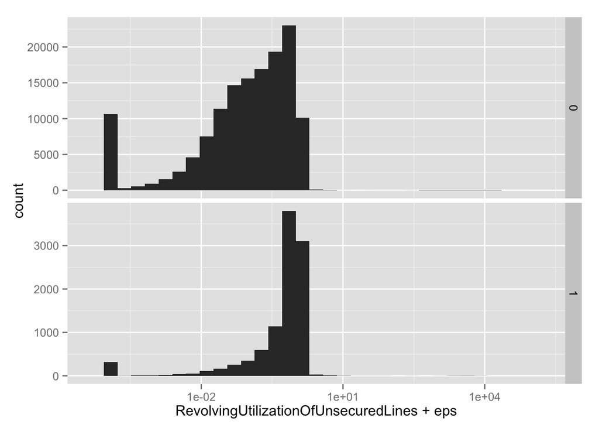

```r
ggplot(d) + geom_histogram(aes(x = RevolvingUtilizationOfUnsecuredLines+eps)) +
  facet_grid(SeriousDlqin2yrs~., scales = "free") + scale_x_log10()
```

```r
d %>% filter(RevolvingUtilizationOfUnsecuredLines>1) %>%
  group_by(SeriousDlqin2yrs) %>% summarize(n = n())
```

```
## Source: local data frame [2 x 2]
##
##   SeriousDlqin2yrs     n
##              (int) (int)
## 1                0  2084
## 2                1  1237
```

```r
d %>% filter(RevolvingUtilizationOfUnsecuredLines>3) %>%
  group_by(SeriousDlqin2yrs) %>% summarize(n = n())
```

```
## Source: local data frame [2 x 2]
##
##   SeriousDlqin2yrs     n
##              (int) (int)
## 1                0   263
## 2                1    29
```

```
## stat_bin: binwidth defaulted to range/30. Use 'binwidth = x' to adjust this.
## stat_bin: binwidth defaulted to range/30. Use 'binwidth = x' to adjust this.
```

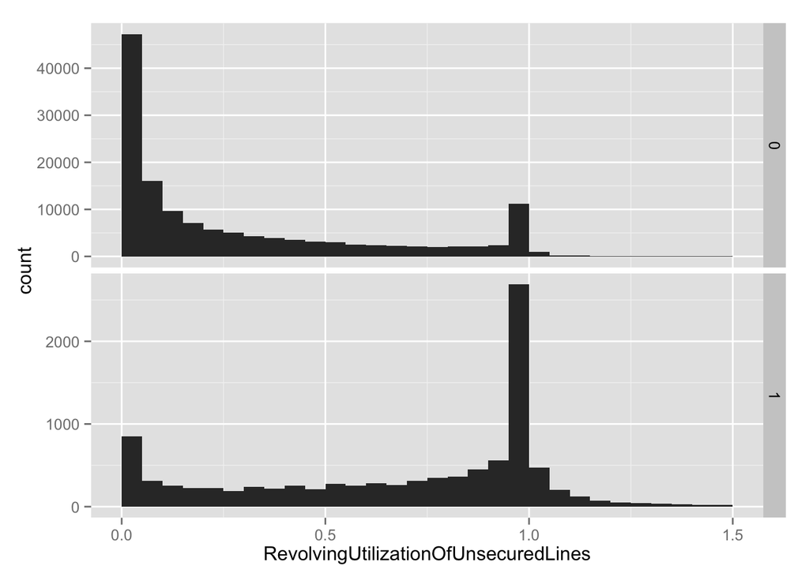

```r
ggplot(d) + geom_histogram(aes(x = RevolvingUtilizationOfUnsecuredLines)) +
  facet_grid(SeriousDlqin2yrs~., scales = "free") + xlim(c(0,1.5))
```

```r
d %>% group_by(SeriousDlqin2yrs) %>%
  summarize(max = max(RevolvingUtilizationOfUnsecuredLines))
```

```
## Source: local data frame [2 x 2]
##
##   SeriousDlqin2yrs   max
##              (int) (dbl)
## 1                0 50708
## 2                1  8328
```

```r
d %>% filter(RevolvingUtilizationOfUnsecuredLines>10) %>%
  select(SeriousDlqin2yrs, RevolvingUtilizationOfUnsecuredLines)
```

```
## Source: local data frame [241 x 2]
##
##    SeriousDlqin2yrs RevolvingUtilizationOfUnsecuredLines
##               (int)                                (dbl)
## 1                 0                                 2340
## 2                 1                                 2066
## 3                 1                                 1143
## 4                 0                                 6324
## 5                 0                                 1982
## 6                 0                                 3746
## 7                 0                                  941
## 8                 0                                 8497
## 9                 1                                 1577
## 10                0                                 1028
## ..              ...                                  ...
```

**Notes/TODO:** clean up outliers

Options:

1. find the errors upstream, correct them
2. truncate for NN/SVM (can leave it for RF/GBM)

### Predictor: age

Age of borrower in years

```r
summary(d$age)
```

```
##    Min. 1st Qu.  Median    Mean 3rd Qu.    Max.
##     0.0    41.0    52.0    52.3    63.0   109.0
```

```
## stat_bin: binwidth defaulted to range/30. Use 'binwidth = x' to adjust this.
## stat_bin: binwidth defaulted to range/30. Use 'binwidth = x' to adjust this.
```

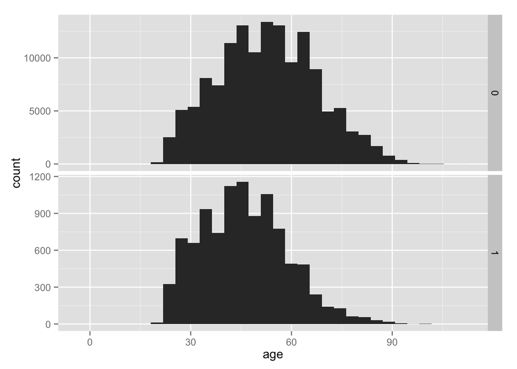

```r
ggplot(d) + geom_histogram(aes(x = age)) +
  facet_grid(SeriousDlqin2yrs~., scales = "free")
```

```r
d %>% filter(age<18) %>%
  group_by(SeriousDlqin2yrs) %>% summarize(n = n())
```

```
## Source: local data frame [1 x 2]
##
##   SeriousDlqin2yrs     n
##              (int) (int)
## 1                0     1
```

```r
d %>% filter(age>90) %>%
  group_by(SeriousDlqin2yrs) %>% summarize(n = n())
```

```
## Source: local data frame [2 x 2]
##
##   SeriousDlqin2yrs     n
##              (int) (int)
## 1                0   478
## 2                1    11
```

### Predictor: NumberOfTime30-59DaysPastDueNotWorse

Number of times borrower has been 30-59 days past due but no worse in the last 2 years.

```r
summary(d$`NumberOfTime30-59DaysPastDueNotWorse`)
```

```
##    Min. 1st Qu.  Median    Mean 3rd Qu.    Max.
##   0.000   0.000   0.000   0.421   0.000  98.000
```

```
## stat_bin: binwidth defaulted to range/30. Use 'binwidth = x' to adjust this.
## stat_bin: binwidth defaulted to range/30. Use 'binwidth = x' to adjust this.
```

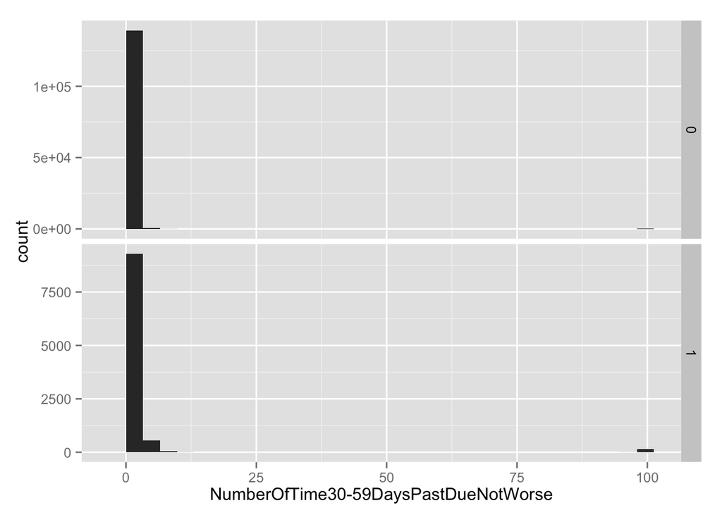

```r
ggplot(d) + geom_histogram(aes(x = `NumberOfTime30-59DaysPastDueNotWorse`)) +
  facet_grid(SeriousDlqin2yrs~., scales = "free")
```

```
## stat_bin: binwidth defaulted to range/30. Use 'binwidth = x' to adjust this.
## stat_bin: binwidth defaulted to range/30. Use 'binwidth = x' to adjust this.
```

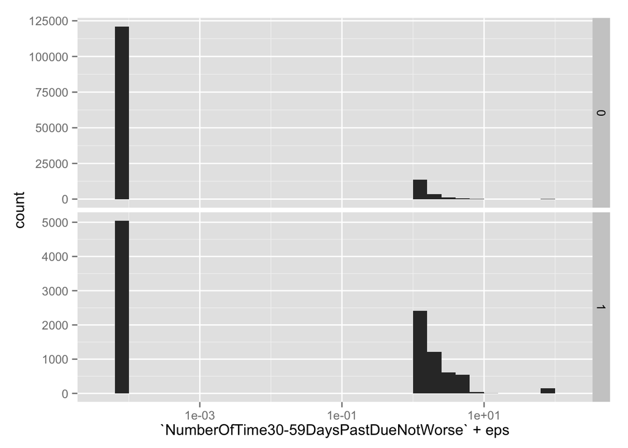

```r
ggplot(d) + geom_histogram(aes(x = `NumberOfTime30-59DaysPastDueNotWorse`+eps)) +
  facet_grid(SeriousDlqin2yrs~., scales = "free") + scale_x_log10()
```

```r
table(d$`NumberOfTime30-59DaysPastDueNotWorse`)
```

```
##
##      0      1      2      3      4      5      6      7      8      9
## 126018  16033   4598   1754    747    342    140     54     25     12
##     10     11     12     13     96     98
##      4      1      2      1      5    264
```

```r
d %>% group_by(SeriousDlqin2yrs, `NumberOfTime30-59DaysPastDueNotWorse`) %>%
  summarize(n = n()) %>% as.data.frame
```

```
##    SeriousDlqin2yrs NumberOfTime30-59DaysPastDueNotWorse      n
## 1                 0                                    0 120977
## 2                 0                                    1  13624
## 3                 0                                    2   3379
## 4                 0                                    3   1136
## 5                 0                                    4    429
## 6                 0                                    5    188
## 7                 0                                    6     66
## 8                 0                                    7     26
## 9                 0                                    8     17
## 10                0                                    9      8
## 11                0                                   10      1
## 12                0                                   12      1
## 13                0                                   96      1
## 14                0                                   98    121
```

[output cut: 16 more lines]

```
## stat_bin: binwidth defaulted to range/30. Use 'binwidth = x' to adjust this.
## stat_bin: binwidth defaulted to range/30. Use 'binwidth = x' to adjust this.
```

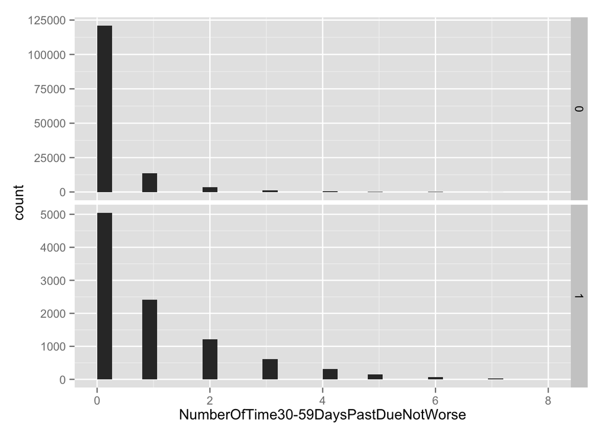

```r
ggplot(d) + geom_histogram(aes(x = `NumberOfTime30-59DaysPastDueNotWorse`)) +
  facet_grid(SeriousDlqin2yrs~., scales = "free") + xlim(c(0,8))
```

**Notes/TODO:** 96,98 is encoding something - needs clean up

### Predictor: DebtRatio

Monthly debt payments, alimony, living costs divided by monthy gross income (percentage)

```r
summary(d$DebtRatio)
```

```
##     Min.  1st Qu.   Median     Mean  3rd Qu.     Max.
##      0.0      0.2      0.4    353.0      0.9 329700.0
```

```
## stat_bin: binwidth defaulted to range/30. Use 'binwidth = x' to adjust this.
## stat_bin: binwidth defaulted to range/30. Use 'binwidth = x' to adjust this.
```

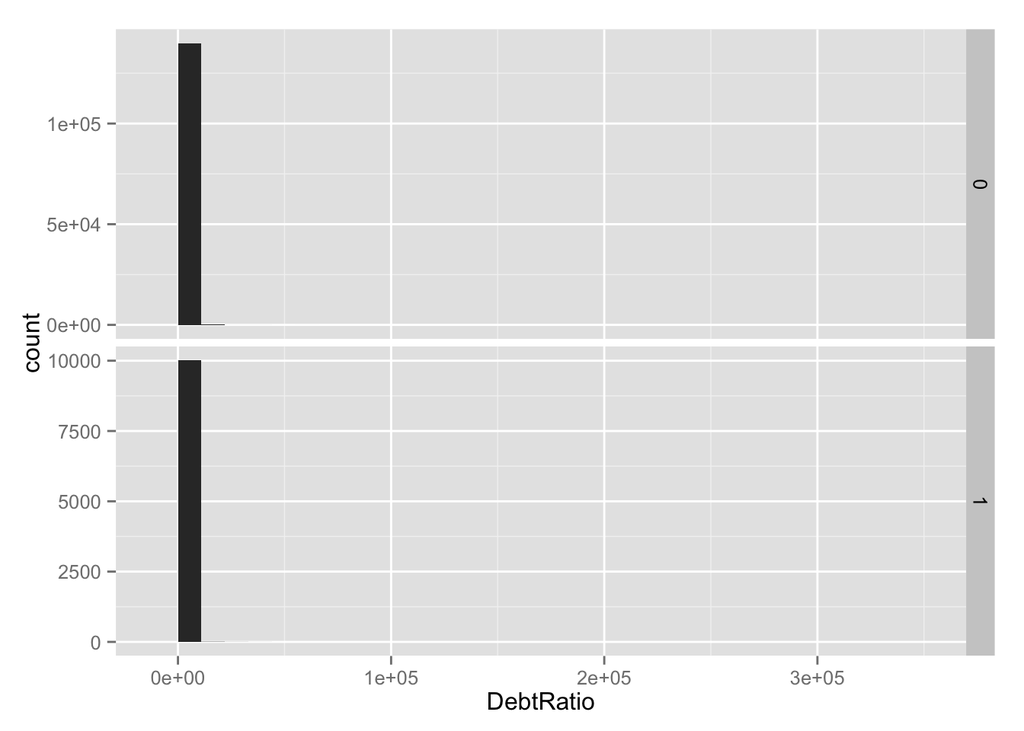

```r
ggplot(d) + geom_histogram(aes(x = DebtRatio)) +
  facet_grid(SeriousDlqin2yrs~., scales = "free")
```

```
## stat_bin: binwidth defaulted to range/30. Use 'binwidth = x' to adjust this.
## stat_bin: binwidth defaulted to range/30. Use 'binwidth = x' to adjust this.
```

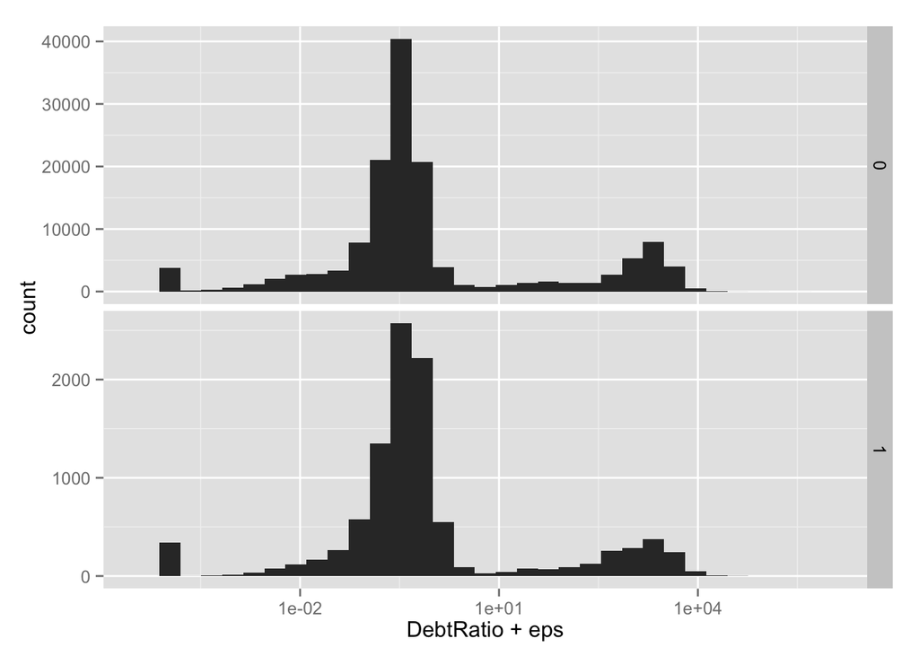

```r
ggplot(d) + geom_histogram(aes(x = DebtRatio+eps)) +
  facet_grid(SeriousDlqin2yrs~., scales = "free") + scale_x_log10()
```

```
## stat_bin: binwidth defaulted to range/30. Use 'binwidth = x' to adjust this.
## stat_bin: binwidth defaulted to range/30. Use 'binwidth = x' to adjust this.
```

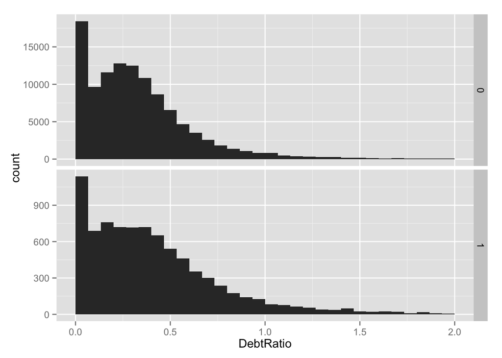

```r
ggplot(d) + geom_histogram(aes(x = DebtRatio)) +
  facet_grid(SeriousDlqin2yrs~., scales = "free") + xlim(c(0,2))
```

```
## stat_bin: binwidth defaulted to range/30. Use 'binwidth = x' to adjust this.
## stat_bin: binwidth defaulted to range/30. Use 'binwidth = x' to adjust this.
```

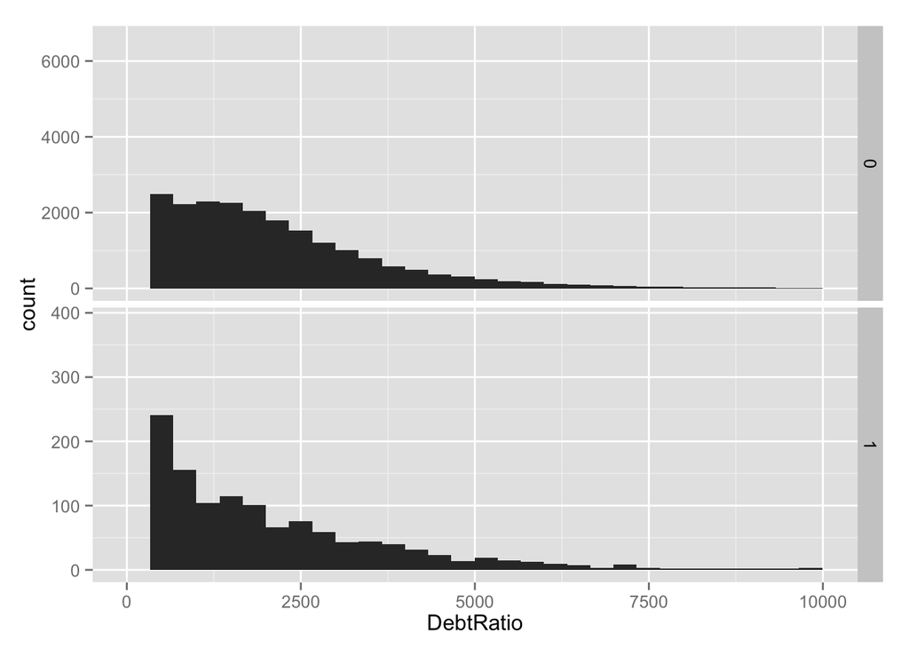

```r
ggplot(d) + geom_histogram(aes(x = DebtRatio)) +
  facet_grid(SeriousDlqin2yrs~., scales = "free") + xlim(c(10,10000))
```

**Notes/TODO:** sometimes ratio, sometimes basis points? - needs cleanup

### Predictor: MonthlyIncome

Monthly income

```r
summary(d$MonthlyIncome)
```

```
##    Min. 1st Qu.  Median    Mean 3rd Qu.    Max.    NA's
##       0    3400    5400    6670    8249 3009000   29731
```

```
## stat_bin: binwidth defaulted to range/30. Use 'binwidth = x' to adjust this.
## stat_bin: binwidth defaulted to range/30. Use 'binwidth = x' to adjust this.
```

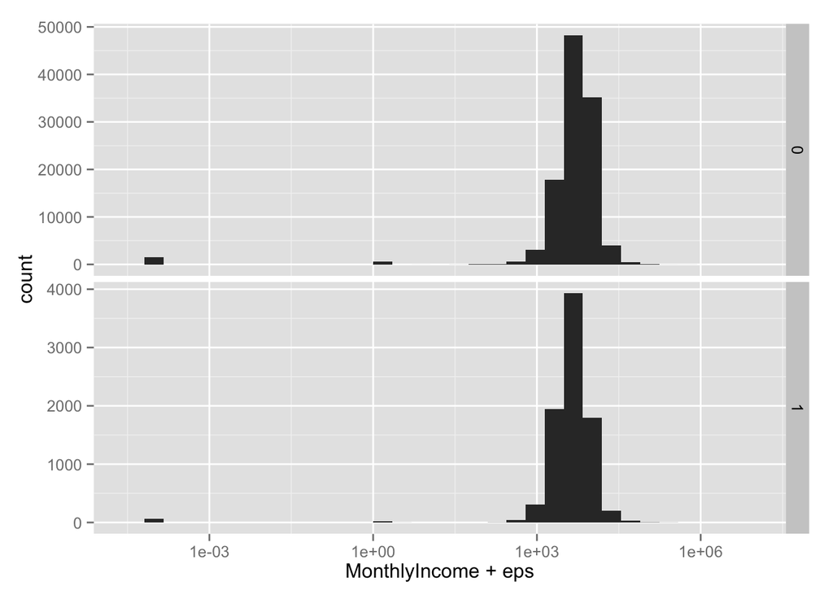

```r
ggplot(d) + geom_histogram(aes(x = MonthlyIncome + eps)) +
  facet_grid(SeriousDlqin2yrs~., scales = "free") + scale_x_log10()
```

```r
d %>% filter(MonthlyIncome < 100) %>%
  group_by(SeriousDlqin2yrs, MonthlyIncome) %>% summarize(n = n()) %>% as.data.frame
```

```
##    SeriousDlqin2yrs MonthlyIncome    n
## 1                 0             0 1568
## 2                 0             1  588
## 3                 0             2    6
## 4                 0             4    1
## 5                 0             5    2
## 6                 0             7    1
## 7                 0             9    1
## 8                 0            10    2
## 9                 0            11    1
## 10                0            15    1
## 11                0            21    1
## 12                0            25    1
## 13                0            27    2
## 14                0            34    1
## 15                0            40    3
## 16                0            42    1
## 17                0            50    4
## 18                0            55    1
## 19                0            56    1
## 20                0            69    1
## 21                0            70    2
## 22                0            72    1
## 23                0            75    1
## 24                0            83    1
## 25                0            84    1
## 26                1             0   66
## 27                1             1   17
## 28                1             4    1
```

```r
d %>% filter(is.na(MonthlyIncome)) %>%
  group_by(SeriousDlqin2yrs) %>% summarize(n = n()) %>% as.data.frame
```

```
##   SeriousDlqin2yrs     n
## 1                0 28062
## 2                1  1669
```

```
## stat_bin: binwidth defaulted to range/30. Use 'binwidth = x' to adjust this.
## stat_bin: binwidth defaulted to range/30. Use 'binwidth = x' to adjust this.
```

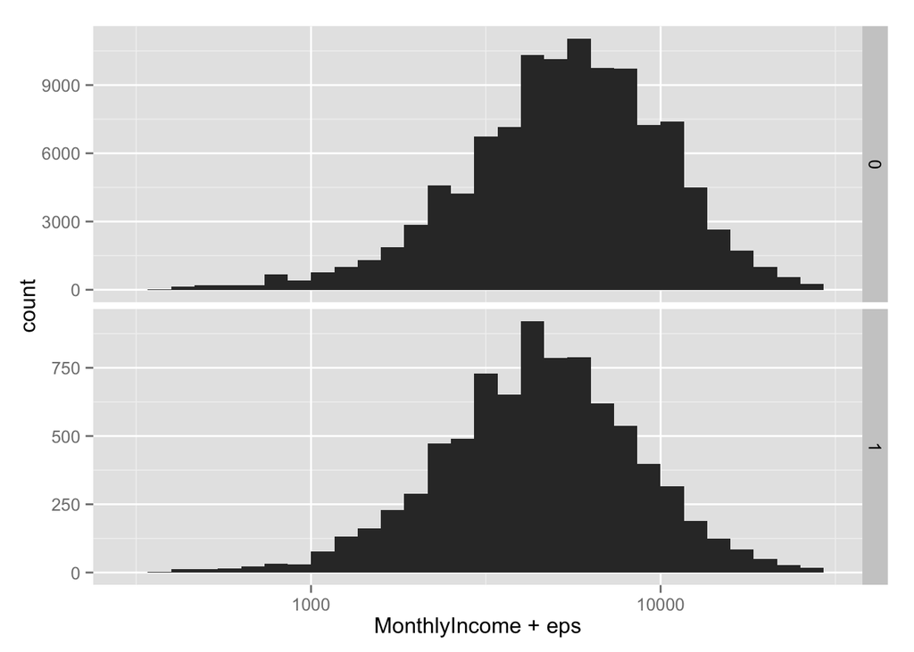

```r
ggplot(d) + geom_histogram(aes(x = MonthlyIncome + eps)) +
  facet_grid(SeriousDlqin2yrs~., scales = "free") + scale_x_log10(limits = c(3e2,3e4))
```

```r
d %>% filter(MonthlyIncome > 1e6) %>% select(SeriousDlqin2yrs, MonthlyIncome) %>%
  as.data.frame
```

```
##   SeriousDlqin2yrs MonthlyIncome
## 1                0       1072500
## 2                0       3008750
## 3                0       1560100
## 4                0       1794060
```

**Notes/TODO:** income is sometimes 0,1 or NA

### Predictor: NumberOfOpenCreditLinesAndLoans

Number of Open loans (installment like car loan or mortgage) and Lines of credit (e.g. credit cards)

```r
summary(d$NumberOfOpenCreditLinesAndLoans)
```

```
##    Min. 1st Qu.  Median    Mean 3rd Qu.    Max.
##   0.000   5.000   8.000   8.453  11.000  58.000
```

```
## stat_bin: binwidth defaulted to range/30. Use 'binwidth = x' to adjust this.
## stat_bin: binwidth defaulted to range/30. Use 'binwidth = x' to adjust this.
```

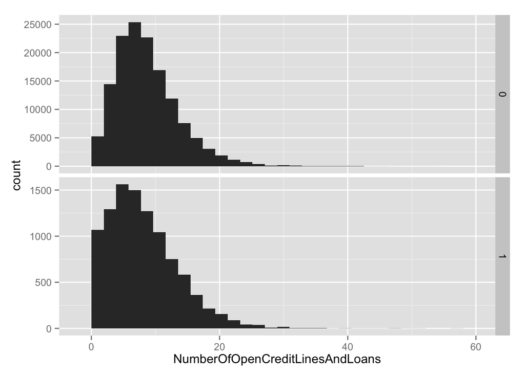

```r
ggplot(d) + geom_histogram(aes(x = NumberOfOpenCreditLinesAndLoans)) +
  facet_grid(SeriousDlqin2yrs~., scales = "free")
```

### Predictor: NumberOfTimes90DaysLate

Number of times borrower has been 90 days or more past due.

```r
summary(d$NumberOfTimes90DaysLate)
```

```
##    Min. 1st Qu.  Median    Mean 3rd Qu.    Max.
##   0.000   0.000   0.000   0.266   0.000  98.000
```

```
## stat_bin: binwidth defaulted to range/30. Use 'binwidth = x' to adjust this.
## stat_bin: binwidth defaulted to range/30. Use 'binwidth = x' to adjust this.
```

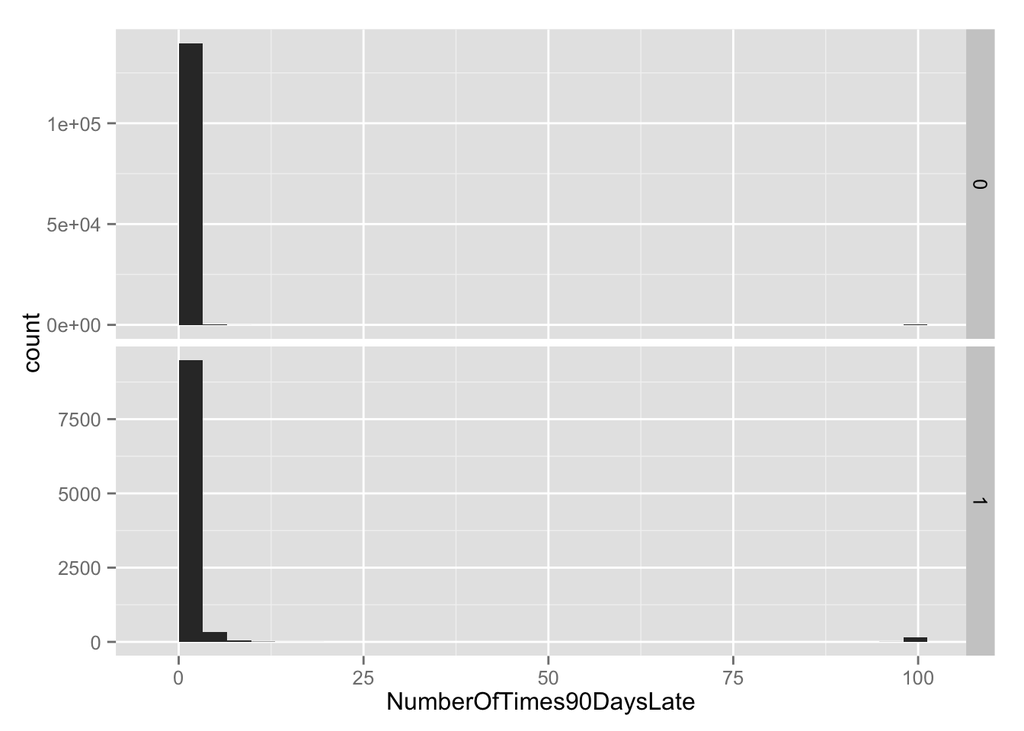

```r
ggplot(d) + geom_histogram(aes(x = NumberOfTimes90DaysLate)) +
  facet_grid(SeriousDlqin2yrs~., scales = "free")
```

```
## stat_bin: binwidth defaulted to range/30. Use 'binwidth = x' to adjust this.
## stat_bin: binwidth defaulted to range/30. Use 'binwidth = x' to adjust this.
```

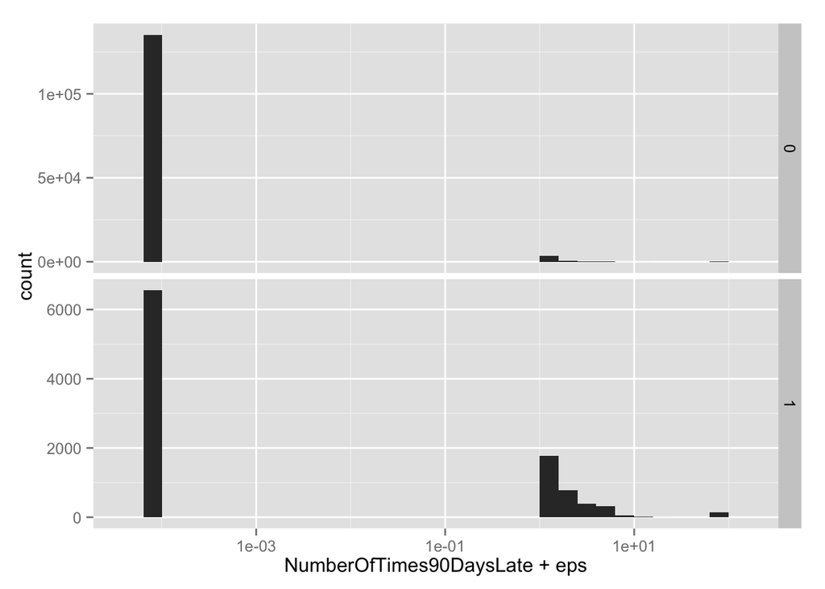

```r
ggplot(d) + geom_histogram(aes(x = NumberOfTimes90DaysLate+eps)) +
  facet_grid(SeriousDlqin2yrs~., scales = "free") + scale_x_log10()
```

```
## stat_bin: binwidth defaulted to range/30. Use 'binwidth = x' to adjust this.
## stat_bin: binwidth defaulted to range/30. Use 'binwidth = x' to adjust this.
```

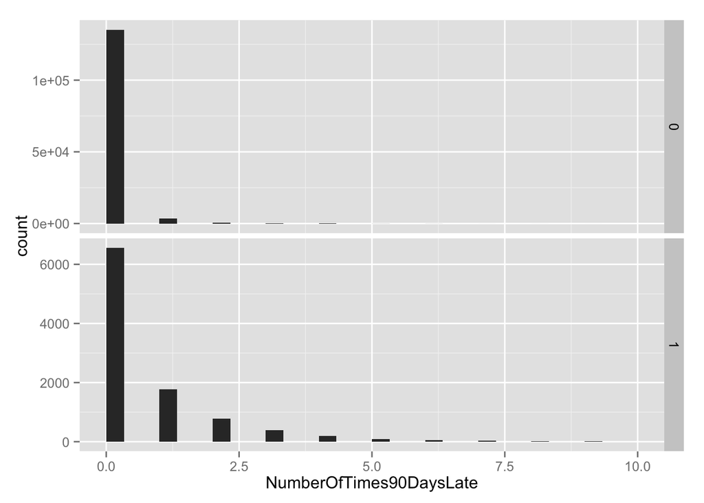

```r
ggplot(d) + geom_histogram(aes(x = NumberOfTimes90DaysLate)) +
  facet_grid(SeriousDlqin2yrs~., scales = "free") + xlim(c(0,10))
```

```r
d %>% group_by(SeriousDlqin2yrs, `NumberOfTimes90DaysLate`) %>%
  summarize(n = n()) %>% as.data.frame
```

```
##    SeriousDlqin2yrs NumberOfTimes90DaysLate      n
## 1                 0                       0 135108
## 2                 0                       1   3478
## 3                 0                       2    779
## 4                 0                       3    282
## 5                 0                       4     96
## 6                 0                       5     48
## 7                 0                       6     32
## 8                 0                       7      7
## 9                 0                       8      6
## 10                0                       9      5
## 11                0                      10      3
## 12                0                      11      2
## 13                0                      12      1
## 14                0                      13      2
```

[output cut: 22 more lines]

**Notes/TODO:** 96/98

### Predictor: NumberRealEstateLoansOrLines

Number of mortgage and real estate loans including home equity lines of credit

```r
summary(d$NumberRealEstateLoansOrLines)
```

```
##    Min. 1st Qu.  Median    Mean 3rd Qu.    Max.
##   0.000   0.000   1.000   1.018   2.000  54.000
```

```
## stat_bin: binwidth defaulted to range/30. Use 'binwidth = x' to adjust this.
## stat_bin: binwidth defaulted to range/30. Use 'binwidth = x' to adjust this.
```

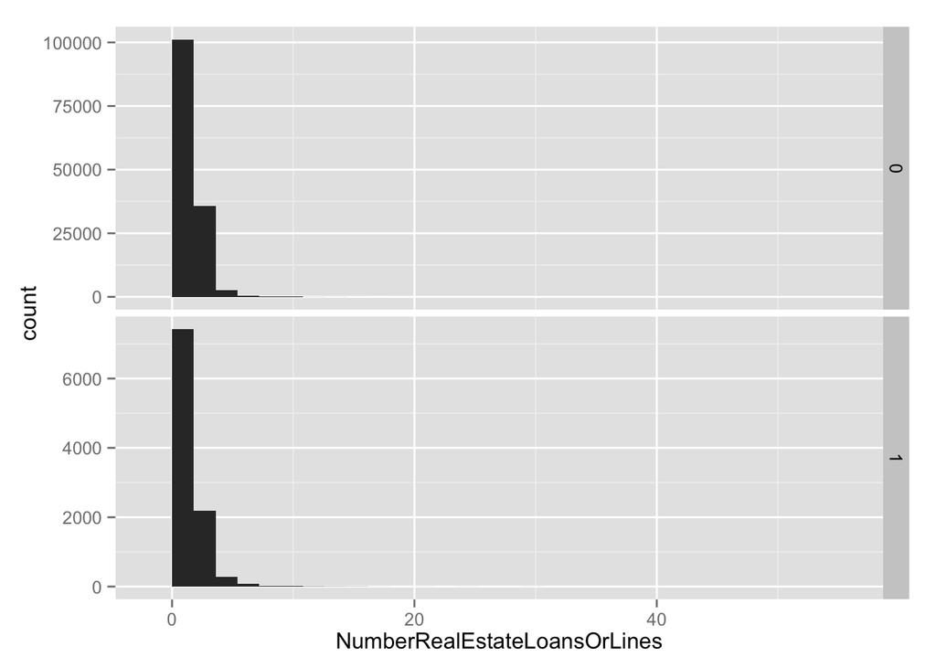

```r
ggplot(d) + geom_histogram(aes(x = NumberRealEstateLoansOrLines)) +
  facet_grid(SeriousDlqin2yrs~., scales = "free")
```

```r
d %>% group_by(SeriousDlqin2yrs, NumberRealEstateLoansOrLines) %>%
  summarize(n = n()) %>% as.data.frame
```

```
##    SeriousDlqin2yrs NumberRealEstateLoansOrLines     n
## 1                 0                            0 51516
## 2                 0                            1 49590
## 3                 0                            2 29757
## 4                 0                            3  5878
## 5                 0                            4  1976
## 6                 0                            5   606
## 7                 0                            6   272
## 8                 0                            7   140
## 9                 0                            8    70
## 10                0                            9    64
## 11                0                           10    32
## 12                0                           11    21
## 13                0                           12    12
## 14                0                           13    10
```

[output cut: 33 more lines]

```
## stat_bin: binwidth defaulted to range/30. Use 'binwidth = x' to adjust this.
## stat_bin: binwidth defaulted to range/30. Use 'binwidth = x' to adjust this.
```

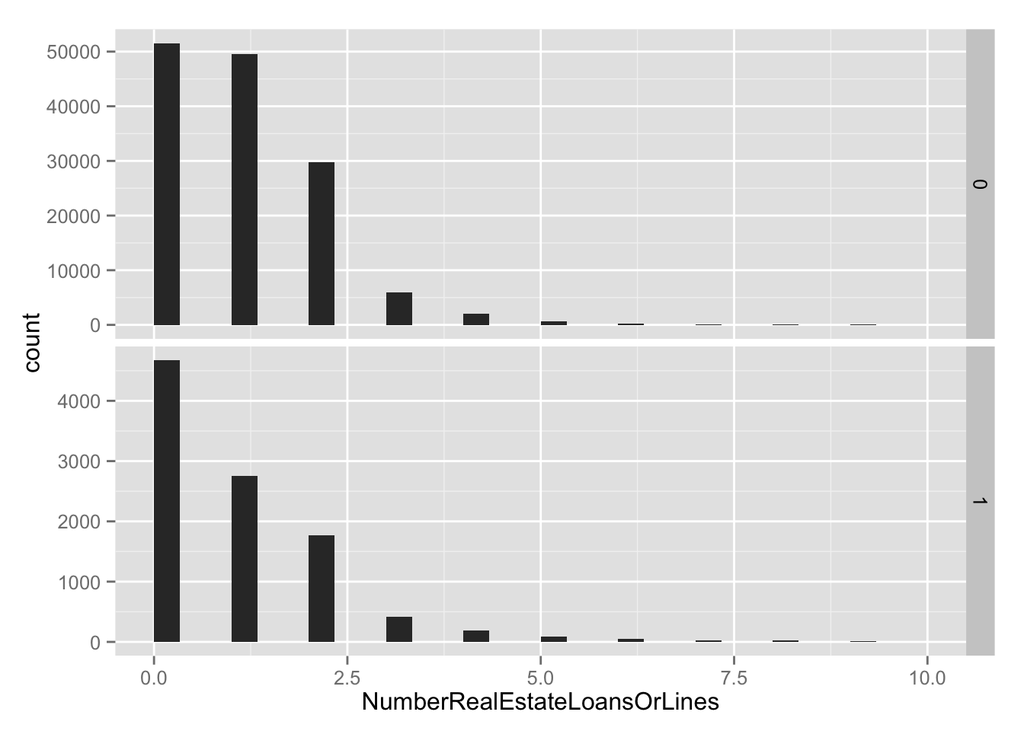

```r
ggplot(d) + geom_histogram(aes(x = NumberRealEstateLoansOrLines)) +
  facet_grid(SeriousDlqin2yrs~., scales = "free") + xlim(c(0,10))
```

### Predictor: NumberOfTime60-89DaysPastDueNotWorse

Number of times borrower has been 60-89 days past due but no worse in the last 2 years.

```r
summary(d$`NumberOfTime60-89DaysPastDueNotWorse`)
```

```
##    Min. 1st Qu.  Median    Mean 3rd Qu.    Max.
##  0.0000  0.0000  0.0000  0.2404  0.0000 98.0000
```

```
## stat_bin: binwidth defaulted to range/30. Use 'binwidth = x' to adjust this.
## stat_bin: binwidth defaulted to range/30. Use 'binwidth = x' to adjust this.
```

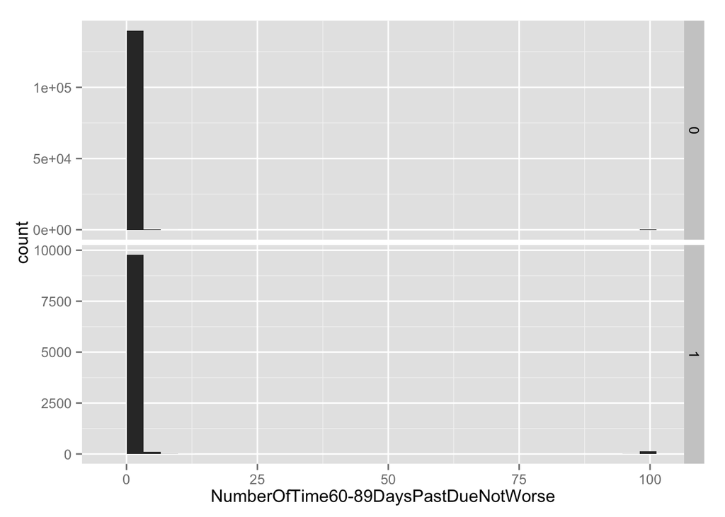

```r
ggplot(d) + geom_histogram(aes(x = `NumberOfTime60-89DaysPastDueNotWorse`)) +
  facet_grid(SeriousDlqin2yrs~., scales = "free")
```

```r
d %>% group_by(SeriousDlqin2yrs, `NumberOfTime60-89DaysPastDueNotWorse`) %>%
  summarize(n = n()) %>% as.data.frame
```

```
##    SeriousDlqin2yrs NumberOfTime60-89DaysPastDueNotWorse      n
## 1                 0                                    0 135140
## 2                 0                                    1   3954
## 3                 0                                    2    557
## 4                 0                                    3    138
## 5                 0                                    4     40
## 6                 0                                    5     13
## 7                 0                                    6      4
## 8                 0                                    7      4
## 9                 0                                    8      1
## 10                0                                    9      1
## 11                0                                   96      1
## 12                0                                   98    121
## 13                1                                    0   7256
## 14                1                                    1   1777
## 15                1                                    2    561
## 16                1                                    3    180
## 17                1                                    4     65
## 18                1                                    5     21
## 19                1                                    6     12
## 20                1                                    7      5
## 21                1                                    8      1
## 22                1                                   11      1
## 23                1                                   96      4
## 24                1                                   98    143
```

```
## stat_bin: binwidth defaulted to range/30. Use 'binwidth = x' to adjust this.
## stat_bin: binwidth defaulted to range/30. Use 'binwidth = x' to adjust this.
```

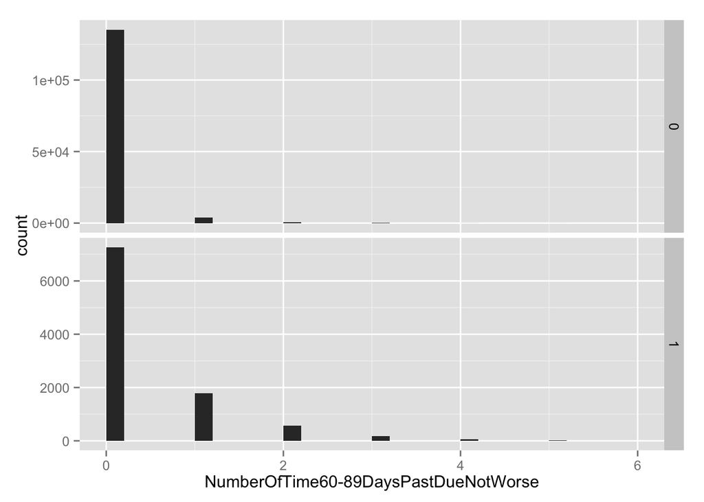

```r
ggplot(d) + geom_histogram(aes(x = `NumberOfTime60-89DaysPastDueNotWorse`)) +
  facet_grid(SeriousDlqin2yrs~., scales = "free") + xlim(c(0,6))
```

**Notes/TODO:** 96/98

### Predictor: NumberOfDependents

Number of dependents in family excluding themselves (spouse, children etc.)

```r
summary(d$NumberOfDependents)
```

```
##    Min. 1st Qu.  Median    Mean 3rd Qu.    Max.    NA's
##   0.000   0.000   0.000   0.757   1.000  20.000    3924
```

```
## stat_bin: binwidth defaulted to range/30. Use 'binwidth = x' to adjust this.
## stat_bin: binwidth defaulted to range/30. Use 'binwidth = x' to adjust this.
```

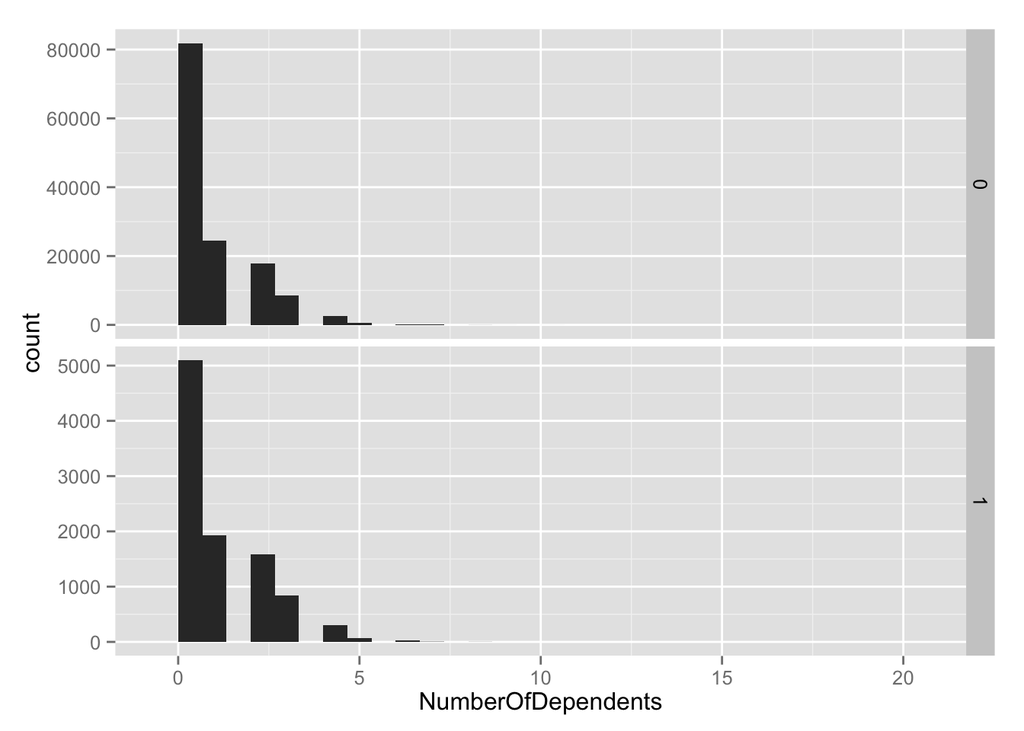

```r
ggplot(d) + geom_histogram(aes(x = NumberOfDependents)) +
  facet_grid(SeriousDlqin2yrs~., scales = "free")
```

```r
d %>% group_by(SeriousDlqin2yrs, NumberOfDependents) %>%
  summarize(n = n()) %>% as.data.frame
```

```
##    SeriousDlqin2yrs NumberOfDependents     n
## 1                 0                  0 81807
## 2                 0                  1 24381
## 3                 0                  2 17938
## 4                 0                  3  8646
## 5                 0                  4  2565
## 6                 0                  5   678
## 7                 0                  6   134
## 8                 0                  7    46
## 9                 0                  8    22
## 10                0                  9     5
## 11                0                 10     5
## 12                0                 13     1
## 13                0                 20     1
## 14                0                 NA  3745
## 15                1                  0  5095
## 16                1                  1  1935
## 17                1                  2  1584
## 18                1                  3   837
## 19                1                  4   297
## 20                1                  5    68
## 21                1                  6    24
## 22                1                  7     5
## 23                1                  8     2
## 24                1                 NA   179
```

```
## stat_bin: binwidth defaulted to range/30. Use 'binwidth = x' to adjust this.
## stat_bin: binwidth defaulted to range/30. Use 'binwidth = x' to adjust this.
```

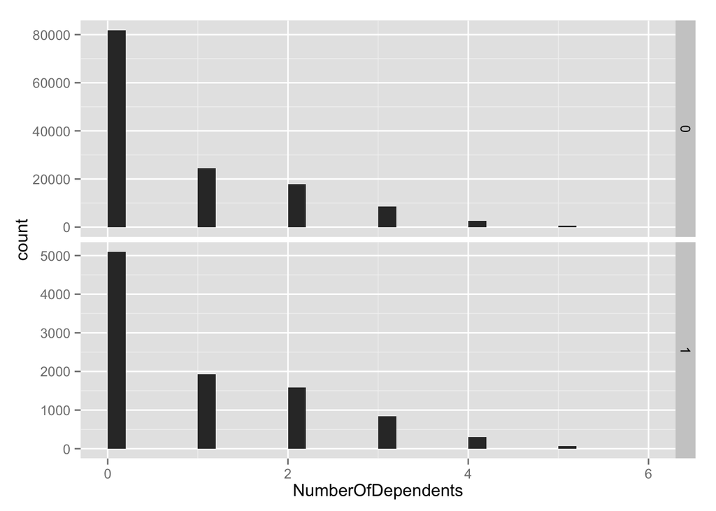

```r
ggplot(d) + geom_histogram(aes(x = NumberOfDependents)) +
  facet_grid(SeriousDlqin2yrs~., scales = "free") + xlim(c(0,6))
```

**Notes/TODO:** Deal with NAs

### Split train/test (could do CV etc.)

```r
d <- d %>% rename(NumberOfTime3059DaysPastDueNotWorse = `NumberOfTime30-59DaysPastDueNotWorse`,
                  NumberOfTime6089DaysPastDueNotWorse = `NumberOfTime60-89DaysPastDueNotWorse`)
colnames(d)
```

```
##  [1] "SeriousDlqin2yrs"
##  [2] "RevolvingUtilizationOfUnsecuredLines"
##  [3] "age"
##  [4] "NumberOfTime3059DaysPastDueNotWorse"
##  [5] "DebtRatio"
##  [6] "MonthlyIncome"
##  [7] "NumberOfOpenCreditLinesAndLoans"
##  [8] "NumberOfTimes90DaysLate"
##  [9] "NumberRealEstateLoansOrLines"
## [10] "NumberOfTime6089DaysPastDueNotWorse"
## [11] "NumberOfDependents"
```

```r
set.seed(123)
N <- nrow(d)
idx_train <- sample(1:N,N/2)
idx_valid <- sample(base::setdiff(1:N, idx_train), N/4)
idx_test <- base::setdiff(base::setdiff(1:N, idx_train),idx_valid)
d_train <- d[idx_train,]
d_valid <- d[idx_valid,]
d_test  <- d[idx_test,]
```

## Data Cleaning

… (based on the **Notes** above)

## Feature Engineering

…

## Modeling

[H2O](http://h2o.ai/) is a powerful open source machine learning platform with R API

### Setup

```r
library(h2o)

h2o.init(max_mem_size = "4g", nthreads = -1)   ## starts Java server (R connects via REST)

dx_train <- as.h2o(d_train)  ## uploads data to H2O
dx_train$SeriousDlqin2yrs <- as.factor(dx_train$SeriousDlqin2yrs)
dx_valid <- as.h2o(d_valid)
dx_valid$SeriousDlqin2yrs <- as.factor(dx_valid$SeriousDlqin2yrs)
dx_test <- as.h2o(d_test)
dx_test$SeriousDlqin2yrs <- as.factor(dx_test$SeriousDlqin2yrs)
```

You can see/check/examine the data in the H2O (Web-based) UI (flow) http://localhost:54321 (or appropriate host)

### Random forest

```r
system.time({
  md <- h2o.randomForest(x = 2:ncol(dx_train), y = 1,
        training_frame = dx_train,
        ntrees = 500, nbins = 200)
})
```

```r
md
```

```
## Model Details:
## ==============
##
## H2OBinomialModel: drf
## Model ID:  DRF_model_R_1451775386923_5
## Model Summary:
##   number_of_trees model_size_in_bytes min_depth max_depth mean_depth
## 1             500            15904563        20        20   20.00000
##   min_leaves max_leaves mean_leaves
## 1       2289       3155  2731.34800
##
##
## H2OBinomialMetrics: drf
## ** Reported on training data. **
## Description: Metrics reported on Out-Of-Bag training samples
##
## MSE:  0.05127992
## R^2:  0.1853802
## LogLoss:  0.1883472
## AUC:  0.8420555
## Gini:  0.6841109
##
## Confusion Matrix for F1-optimal threshold:
##            0    1    Error         Rate
## 0      65332 4605 0.065845  =4605/69937
## 1       2489 2574 0.491606   =2489/5063
## Totals 67821 7179 0.094587  =7094/75000
##
## Maximum Metrics: Maximum metrics at their respective thresholds
##                       metric threshold    value idx
## 1                     max f1  0.199634 0.420520 196
## 2                     max f2  0.100147 0.503975 257
## 3               max f0point5  0.414270 0.432972 114
## 4               max accuracy  0.568621 0.935507  66
## 5              max precision  0.919714 1.000000   0
## 6           max absolute_MCC  0.199634 0.377403 196
## 7 max min_per_class_accuracy  0.056965 0.766147 297
```

```r
h2o.auc(md)
```

```
## [1] 0.8420555
```

```r
h2o.auc(h2o.performance(md, dx_test))
```

```
## [1] 0.8503285
```

You can examine model in the UI http://localhost:54321

### GBM

```r
system.time({
  md <- h2o.gbm(x = 2:ncol(dx_train), y = 1,
        training_frame = dx_train, validation_frame = dx_valid,
        max_depth = 15, ntrees = 500, learn_rate = 0.01, nbins = 200,
        stopping_rounds = 3, stopping_tolerance = 1e-3)
})
```

```r
md
```

```
## Model Details:
## ==============
##
## H2OBinomialModel: gbm
## Model ID:  GBM_model_R_1451775386923_10
## Model Summary:
##   number_of_trees model_size_in_bytes min_depth max_depth mean_depth
## 1             500             3337857        15        15   15.00000
##   min_leaves max_leaves mean_leaves
## 1         82       1179   567.85000
##
##
## H2OBinomialMetrics: gbm
## ** Reported on training data. **
##
## MSE:  0.02700474
## R^2:  0.5710096
## LogLoss:  0.1050223
## AUC:  0.969526
## Gini:  0.9390521
##
## Confusion Matrix for F1-optimal threshold:
##            0    1    Error         Rate
## 0      69393  544 0.007778   =544/69937
## 1       1628 3435 0.321548   =1628/5063
## Totals 71021 3979 0.028960  =2172/75000
##
## Maximum Metrics: Maximum metrics at their respective thresholds
##                       metric threshold    value idx
## 1                     max f1  0.325414 0.759788 165
## 2                     max f2  0.158323 0.760004 228
## 3               max f0point5  0.449714 0.847731 131
## 4               max accuracy  0.358374 0.971280 154
## 5              max precision  0.959244 1.000000   0
## 6           max absolute_MCC  0.325414 0.750737 165
## 7 max min_per_class_accuracy  0.083997 0.901783 271
##
## H2OBinomialMetrics: gbm
## ** Reported on validation data. **
##
## MSE:  0.05302311
## R^2:  0.1462572
## LogLoss:  0.195005
## AUC:  0.829411
## Gini:  0.6588219
##
## Confusion Matrix for F1-optimal threshold:
##            0    1    Error         Rate
## 0      33175 1830 0.052278  =1830/35005
## 1       1420 1075 0.569138   =1420/2495
## Totals 34595 2905 0.086667  =3250/37500
##
## Maximum Metrics: Maximum metrics at their respective thresholds
##                       metric threshold    value idx
## 1                     max f1  0.205891 0.398148 205
## 2                     max f2  0.069239 0.476643 284
## 3               max f0point5  0.370842 0.402754 142
## 4               max accuracy  0.607341 0.934987  75
## 5              max precision  0.945428 0.714286   1
## 6           max absolute_MCC  0.211378 0.353052 203
## 7 max min_per_class_accuracy  0.041741 0.752978 317
```

```r
h2o.auc(md)
```

```
## [1] 0.969526
```

```r
h2o.auc(h2o.performance(md, dx_test))
```

```
## [1] 0.8412587
```